# Project 1 Checkpoint 4

Author

Mira Griffin, Eloise Melendez, Chloe Schurter

## Do certain months of the year tend to have a higher amount of suspected measles cases, for different countries?

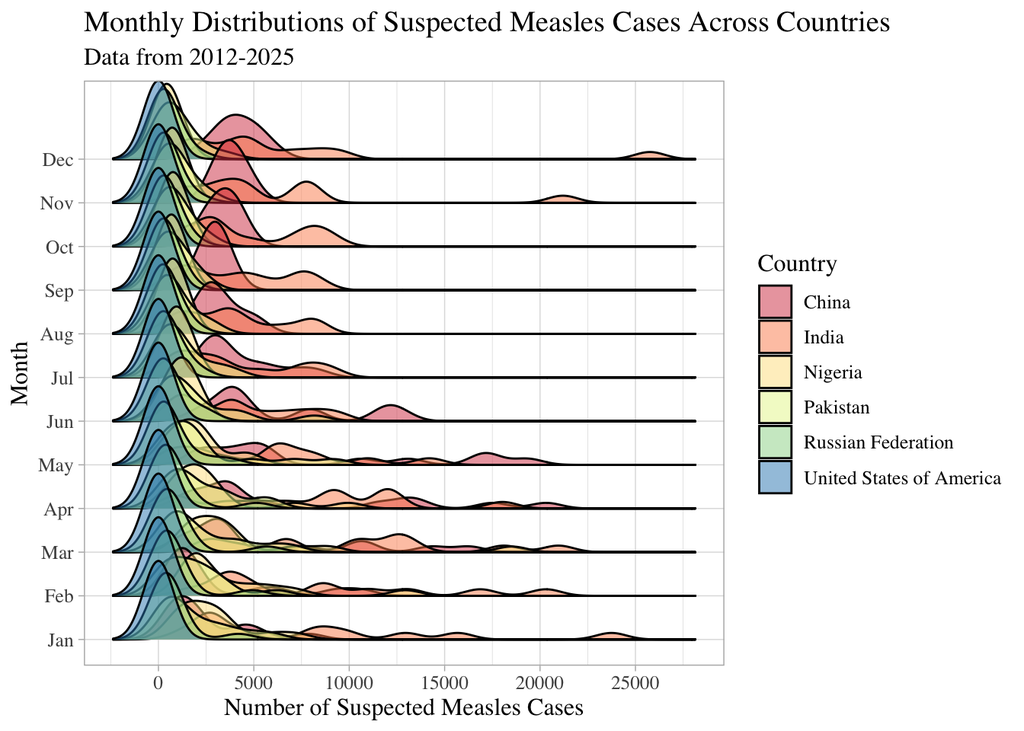

```r
top_pop <- cases_year |>
  group_by(region) |>
  slice_max(order_by = total_population, n = 1, with_ties = FALSE)

top_pop_month <- left_join(top_pop, cases_month, by = "country")

top_pop_month$month <- factor(top_pop_month$month,
                              levels = 1:12,
                              labels = c("Jan", "Feb", "Mar","Apr",                                          "May","Jun", "Jul", "Aug",                                          "Sep", "Oct", "Nov",                                               "Dec"))

ggplot(data = top_pop_month,
       mapping = aes(x = measles_suspect,
                     y = month,
                     fill = country)) +
  geom_density_ridges(alpha = 0.5) +
  labs(x = "Number of Suspected Measles Cases",
       y = "Month",
       fill = "Country",
       title = "Monthly Distributions of Suspected Measles Cases Across Countries",
       subtitle = "Data from 2012-2025") +
  scale_x_continuous(breaks = seq(0, 30000, 5000)) +
  scale_fill_brewer(palette = "Spectral") +
  theme_light() +
  theme(text = element_text(family = "Times", size = 12))
```

## Is the ratio of measles cases to rubella cases per year different depending on the country? (mutate)

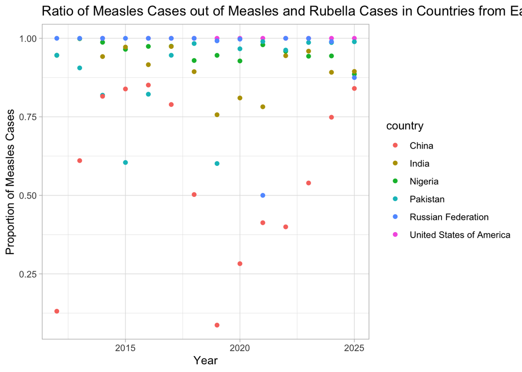

```r
ggplot(data = measles_prop,
      mapping = aes(x = year,
                    y = prop_tot_measles_per_year,
                    color = country)) +
 geom_point() +
 theme_light() +
 ggtitle("Ratio of Measles Cases out of Measles and Rubella Cases in Countries from Each Region with the Highest Population"
 ) +
 labs(x = "Year", y = "Proportion of Measles Cases")
```

## Multiple Linear Regression Model for Measles Proportion by Country and Year

```r
model_table <- model_df |>
  gt() |>
  tab_header(
    title = md("Multiple Linear Regression Model for Measles Proportion by Country and Year")
  ) |>
  tab_caption(
    caption = md("Estimates of differences in measles proportion (relative to the reference country), in descending order")) |>

  tab_style(
    style = cell_text(weight = "bold"),
    locations = cells_column_labels()
  ) |>
  fmt_percent( columns = Estimate) |>
  cols_label(
    term = "Country",
    Estimate = "Estimate",
    `Std. Error` = "Std Error",
    `t value` = "t-value",
    `p value` = "p-value"
  ) |>
  fmt_number(columns = -c(term, Estimate),
             decimals = 4
  )

model_table
```

Estimates of differences in measles proportion (relative to the reference country), in descending order

Multiple Linear Regression Model for Measles Proportion by Country and Year

| Country | Estimate | Std Error | t-value | p-value |
| --- | --- | --- | --- | --- |
| (Intercept) | −1,758.20% | 2.5350 | −6.9300 | 0.0000 |
| Poland | −69.90% | 0.0800 | −8.7600 | 0.0000 |
| Botswana | −62.10% | 0.0810 | −7.6400 | 0.0000 |
| Zimbabwe | −61.30% | 0.0800 | −7.6900 | 0.0000 |
| Eswatini | −58.70% | 0.0870 | −6.7200 | 0.0000 |
| Madagascar | −57.20% | 0.0800 | −7.1800 | 0.0000 |
| Lesotho | −55.00% | 0.0830 | −6.6200 | 0.0000 |
| South Africa | −54.10% | 0.0810 | −6.6600 | 0.0000 |
| Tunisia | −51.00% | 0.0800 | −6.4000 | 0.0000 |
| Cambodia | −42.30% | 0.0810 | −5.2000 | 0.0000 |
| Democratic People's Republic of Korea | −39.40% | 0.1600 | −2.4700 | 0.0140 |
| China | −38.90% | 0.0800 | −4.8800 | 0.0000 |
| Malawi | −38.80% | 0.0800 | −4.8700 | 0.0000 |
| Guinea-Bissau | −37.30% | 0.1200 | −3.1100 | 0.0020 |
| Fiji | −36.60% | 0.0900 | −4.0600 | 0.0000 |
| Timor-Leste | −36.00% | 0.0810 | −4.4300 | 0.0000 |
| Mongolia | −35.70% | 0.0900 | −3.9600 | 0.0000 |
| Lao People's Democratic Republic | −32.80% | 0.0810 | −4.0300 | 0.0000 |
| Papua New Guinea | −31.90% | 0.0870 | −3.6500 | 0.0000 |
| Vanuatu | −30.60% | 0.1340 | −2.2800 | 0.0230 |
| Morocco | −28.30% | 0.0800 | −3.5500 | 0.0000 |
| Bangladesh | −28.10% | 0.0800 | −3.5200 | 0.0000 |
| Japan | −27.50% | 0.0800 | −3.4500 | 0.0010 |
| Latvia | −26.30% | 0.0940 | −2.8100 | 0.0050 |
| Côte d'Ivoire | −26.10% | 0.0800 | −3.2700 | 0.0010 |
| Eritrea | −25.70% | 0.0810 | −3.1600 | 0.0020 |
| Burundi | −25.20% | 0.0800 | −3.1700 | 0.0020 |
| Bhutan | −23.40% | 0.0940 | −2.5000 | 0.0130 |
| Zambia | −23.00% | 0.0800 | −2.8800 | 0.0040 |
| Mozambique | −22.40% | 0.0800 | −2.8100 | 0.0050 |

[output cut: 140 more lines]

This model is statistically significant, and it can be concluded that at least one country or year effect differs in the proportion of measles to rubella cases. (F = 7.047, df = 169, p value = 2.2e-16). About 42.08% of the variation in proportions of measles to rubella cases can be explained by country and year (R^2 = 0.4208). Year was a significant positive predictor in proportion of measles cases over many years. (estimate = 9.181e-03, p value = 4.14e-13)

We can see that the top 5 countries with the largest absolute difference in measles proportions relative to the reference country are Poland (largest), Botswana, Zimbabwe, Eswatini and Madagascar. For example, Poland has the largest difference in percent (69.90% less than the reference country)